# Summer Internship

Navin Ramanan

6/01/2022

```
## Cortex: Running DESeq2 for Diet(Control vs Supplemented) with APP=WT, Age=9:padj < 0.05 and 0.10
```

```
## Cortex: WT9Control vs WT9Supplemented
```

```
## resultsNames:
```

```
##  [1] "Intercept"
##  [2] "group_APP12Supplemented_vs_APP12Control"
##  [3] "group_APP3Control_vs_APP12Control"
##  [4] "group_APP3Supplemented_vs_APP12Control"
##  [5] "group_APP6Control_vs_APP12Control"
##  [6] "group_APP6Supplemented_vs_APP12Control"
##  [7] "group_APP9Control_vs_APP12Control"
##  [8] "group_APP9Supplemented_vs_APP12Control"
##  [9] "group_WT12Control_vs_APP12Control"
## [10] "group_WT12Supplemented_vs_APP12Control"
## [11] "group_WT3Control_vs_APP12Control"
## [12] "group_WT3Supplemented_vs_APP12Control"
## [13] "group_WT6Control_vs_APP12Control"
## [14] "group_WT6Supplemented_vs_APP12Control"
## [15] "group_WT9Control_vs_APP12Control"
## [16] "group_WT9Supplemented_vs_APP12Control"
## [1] "group"           "WT9Control"      "WT9Supplemented"
##
## out of 34880 with nonzero total read count
## adjusted p-value < 0.1
## LFC > 0 (up)       : 2, 0.0057%
## LFC < 0 (down)     : 3, 0.0086%
## outliers [1]       : 101, 0.29%
## low counts [2]     : 0, 0%
## (mean count < 0)
## [1] see 'cooksCutoff' argument of ?results
## [2] see 'independentFiltering' argument of ?results
```

```
## log2 fold change (MLE): group WT9Control vs WT9Supplemented
## Wald test p-value: group WT9Control vs WT9Supplemented
## DataFrame with 10 rows and 6 columns
##                     baseMean log2FoldChange     lfcSE      stat      pvalue
##                    <numeric>      <numeric> <numeric> <numeric>   <numeric>
## ENSMUSG00000020872   4.59722     -18.150931  1.904305 -9.531525 1.54990e-21
## ENSMUSG00000084902   1.66653     -17.287945  2.910737 -5.939370 2.86120e-09
## ENSMUSG00000110266   1.67263      17.771461  2.987528  5.948550 2.70528e-09
## ENSMUSG00000050366   1.42079      16.690773  3.049938  5.472496 4.43742e-08
## ENSMUSG00000048620   2.42172     -17.377346  3.906338 -4.448501 8.64718e-06
## ENSMUSG00000057967  76.21996       0.802169  0.210390  3.812777 1.37414e-04
## ENSMUSG00000099974  13.46839      -3.091204  0.829303 -3.727472 1.93410e-04
## ENSMUSG00000064372 542.10660      -0.887605  0.237878 -3.731344 1.90461e-04
## ENSMUSG00000111474  56.31519      -0.790578  0.214823 -3.680140 2.33106e-04
## ENSMUSG00000102628  17.92210      -0.249099  0.469116 -0.530996 5.95422e-01
##                           padj
##                      <numeric>
## ENSMUSG00000020872 5.39038e-17
## ENSMUSG00000084902 3.31698e-05
## ENSMUSG00000110266 3.31698e-05
## ENSMUSG00000050366 3.85822e-04
## ENSMUSG00000048620 6.01480e-02
## ENSMUSG00000057967 7.96522e-01
## ENSMUSG00000099974 8.40825e-01
## ENSMUSG00000064372 8.40825e-01
## ENSMUSG00000111474 9.00800e-01
## ENSMUSG00000102628 1.00000e+00
```

```
## log2 fold change (MLE): group WT9Control vs WT9Supplemented
## Wald test p-value: group WT9Control vs WT9Supplemented
## DataFrame with 34880 rows and 6 columns
##                       baseMean log2FoldChange     lfcSE       stat      pvalue
##                      <numeric>      <numeric> <numeric>  <numeric>   <numeric>
## ENSMUSG00000020872     4.59722       -18.1509   1.90430   -9.53152 1.54990e-21
## ENSMUSG00000084902     1.66653       -17.2879   2.91074   -5.93937 2.86120e-09
## ENSMUSG00000110266     1.67263        17.7715   2.98753    5.94855 2.70528e-09
## ENSMUSG00000050366     1.42079        16.6908   3.04994    5.47250 4.43742e-08
## ENSMUSG00000048620     2.42172       -17.3773   3.90634   -4.44850 8.64718e-06
## ...                        ...            ...       ...        ...         ...
## ENSMUSG00000109212    0.769426      0.0000000  8.245409  0.0000000          NA
## ENSMUSG00000054134   40.269651     -0.0258689  0.753248 -0.0343432          NA
## ENSMUSG00000024028    0.789155      0.0000000  8.245409  0.0000000          NA
## ENSMUSG00000061808 1664.189531      0.0365690  0.829116  0.0441060          NA
## ENSMUSG00000037451    1.547250      0.0000000  8.245409  0.0000000          NA
##                           padj
##                      <numeric>
## ENSMUSG00000020872 5.39038e-17
## ENSMUSG00000084902 3.31698e-05
## ENSMUSG00000110266 3.31698e-05
## ENSMUSG00000050366 3.85822e-04
## ENSMUSG00000048620 6.01480e-02
## ...                        ...
## ENSMUSG00000109212          NA
## ENSMUSG00000054134          NA
## ENSMUSG00000024028          NA
## ENSMUSG00000061808          NA
## ENSMUSG00000037451          NA
```

```
## class: DESeqDataSet
## dim: 34880 96
## metadata(1): version
## assays(4): counts mu H cooks
## rownames(34880): ENSMUSG00000102628 ENSMUSG00000097426 ...
##   ENSMUSG00000095041 ENSMUSG00000095742
## rowData names(78): baseMean baseVar ... deviance maxCooks
## colnames(96): 102 103 ... 95 96
## colData names(6): Sex Diet ... group sizeFactor
```

```
## Cortex DESeq2 result is saved in file: 'Cortex_deseq_results_Diet_WT_9.csv'
```

```
## Cortex DESeq2 normalized counts is saved in file: 'Cortex_deseq_norm_counts_Diet_WT_9.csv'
```

```
## Cortex DESeq2 result with Gene names (mgi_symbols) is saved in file: 'Cortex_deseq_results_with_genename_Diet_WT_9.csv'
```

```
## [1] 34880
```

```
## [1] 4
```

```
## Cortex DESeq2 result after padj (0.05) filtering is saved in file: 'Cortex_deseq_results_Diet_WT_9_padj_05_filtered.csv'
```

```
## Number of DE genes significant at padj < 0.05 for Cortex:WT9Control vs WT9Supplemented: 4
```

```
## Number of DE genes discarded after padj threshold 0.05 filtering for Cortex:WT9Control vs WT9Supplemented: 34876
```

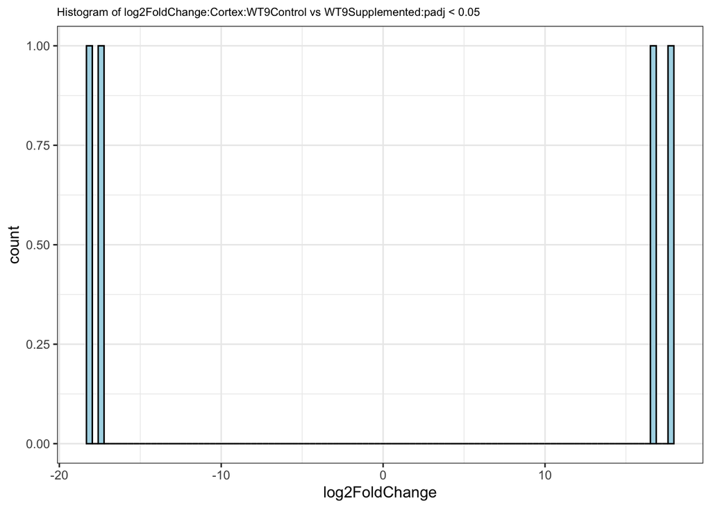

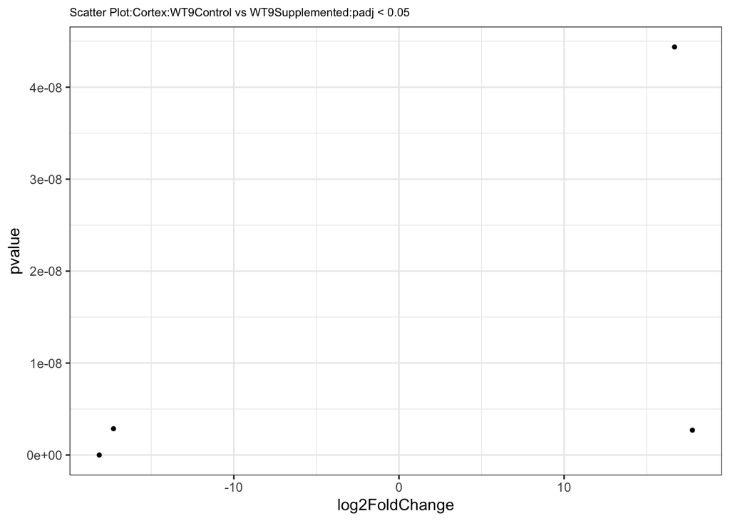

```
## [1] 34880
```

```
## [1] 5
```

```
## Cortex DESeq2 result after padj (0.1) filtering is saved in file: 'Cortex_deseq_results_Diet_WT_9_padj_1_filtered.csv'
```

```
## Number of DE genes significant at padj < 0.1 for Cortex:WT9Control vs WT9Supplemented: 5
```

```
## Number of DE genes discarded after padj threshold 0.1 filtering for Cortex:WT9Control vs WT9Supplemented: 34875
```

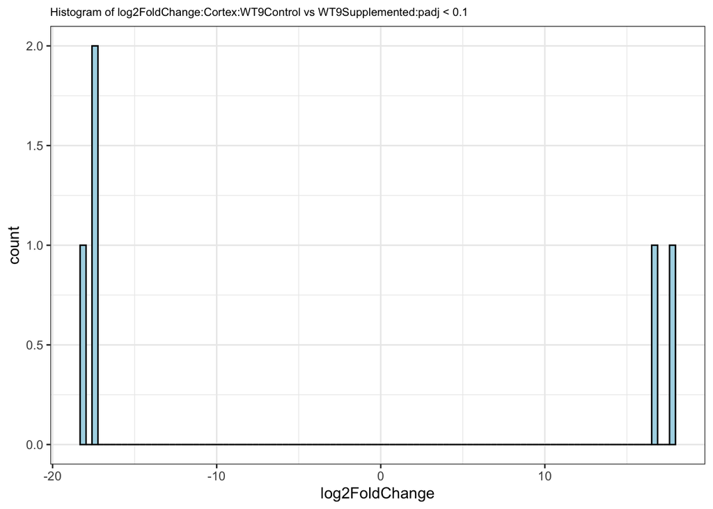

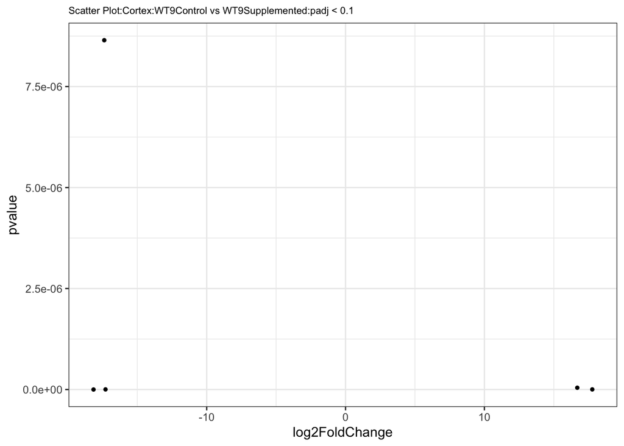

6. Cortex: Enhanced Volcano Plot

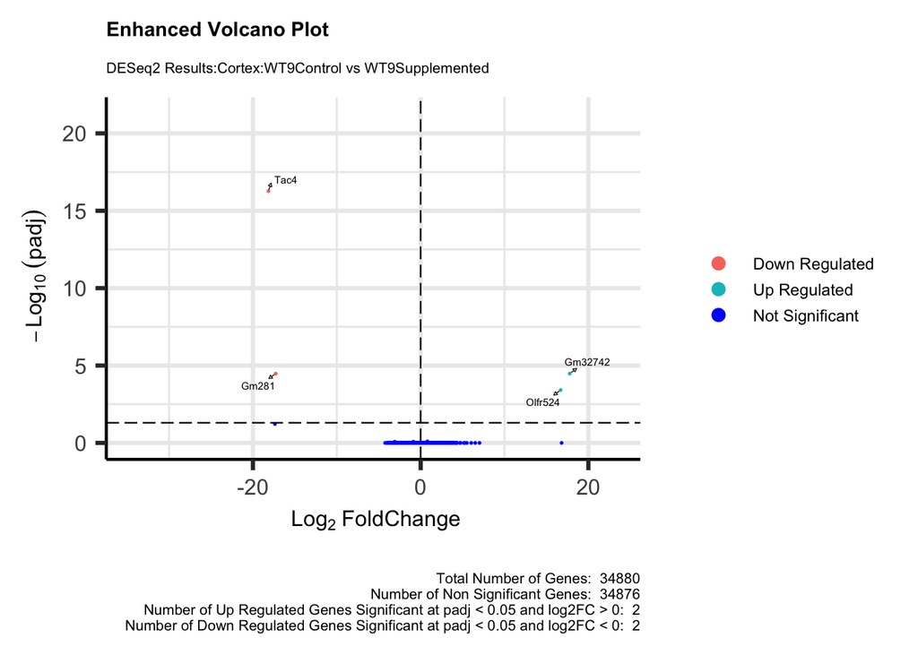

7. Cortex: Heatmap

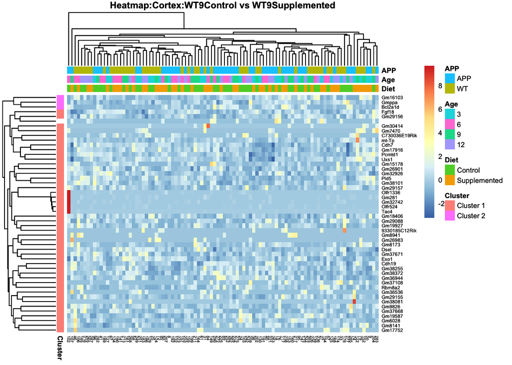

```
## Hippocampus: Running DESeq2 for Diet(Control vs Supplemented) with APP=WT, Age=9:padj < 0.05 and 0.10
```

```
## Hippocampus: WT9Control vs WT9Supplemented
```

```
## resultsNames:
```

```
##  [1] "Intercept"
##  [2] "group_APP12Supplemented_vs_APP12Control"
##  [3] "group_APP3Control_vs_APP12Control"
##  [4] "group_APP3Supplemented_vs_APP12Control"
##  [5] "group_APP6Control_vs_APP12Control"
##  [6] "group_APP6Supplemented_vs_APP12Control"
##  [7] "group_APP9Control_vs_APP12Control"
##  [8] "group_APP9Supplemented_vs_APP12Control"
##  [9] "group_WT12Control_vs_APP12Control"
## [10] "group_WT12Supplemented_vs_APP12Control"
## [11] "group_WT3Control_vs_APP12Control"
## [12] "group_WT3Supplemented_vs_APP12Control"
## [13] "group_WT6Control_vs_APP12Control"
## [14] "group_WT6Supplemented_vs_APP12Control"
## [15] "group_WT9Control_vs_APP12Control"
## [16] "group_WT9Supplemented_vs_APP12Control"
## [1] "group"           "WT9Control"      "WT9Supplemented"
##
## out of 33271 with nonzero total read count
## adjusted p-value < 0.1
## LFC > 0 (up)       : 0, 0%
## LFC < 0 (down)     : 0, 0%
## outliers [1]       : 77, 0.23%
## low counts [2]     : 0, 0%
## (mean count < 0)
## [1] see 'cooksCutoff' argument of ?results
## [2] see 'independentFiltering' argument of ?results
```

```
## log2 fold change (MLE): group WT9Control vs WT9Supplemented
## Wald test p-value: group WT9Control vs WT9Supplemented
## DataFrame with 10 rows and 6 columns
##                       baseMean log2FoldChange     lfcSE       stat      pvalue
##                      <numeric>      <numeric> <numeric>  <numeric>   <numeric>
## ENSMUSG00000084371   12.435791      1.7234808  0.407721  4.2271067 2.36715e-05
## ENSMUSG00000068129  933.482069     -1.5563690  0.359814 -4.3254857 1.52196e-05
## ENSMUSG00000102628    4.933073      0.4995491  0.712631  0.7009931 4.83307e-01
## ENSMUSG00000086053    1.288311      0.2563595  1.570723  0.1632111 8.70352e-01
## ENSMUSG00000102135    0.260071     -1.1087931  4.987618 -0.2223091 8.24073e-01
## ENSMUSG00000100764    7.786530     -0.5852071  0.685690 -0.8534574 3.93406e-01
## ENSMUSG00000100635   10.643846      1.4896128  1.027993  1.4490490 1.47324e-01
## ENSMUSG00000100480   40.881695     -0.1832043  0.328504 -0.5576928 5.77054e-01
## ENSMUSG00000100025    9.761216      0.0283343  0.521654  0.0543162 9.56683e-01
## ENSMUSG00000051285 7467.607010     -0.0113313  0.225228 -0.0503103 9.59875e-01
##                         padj
##                    <numeric>
## ENSMUSG00000084371  0.392877
## ENSMUSG00000068129  0.392877
## ENSMUSG00000102628  1.000000
## ENSMUSG00000086053  1.000000
## ENSMUSG00000102135  1.000000
## ENSMUSG00000100764  1.000000
## ENSMUSG00000100635  1.000000
## ENSMUSG00000100480  1.000000
## ENSMUSG00000100025  1.000000
## ENSMUSG00000051285  1.000000
```

```
## log2 fold change (MLE): group WT9Control vs WT9Supplemented
## Wald test p-value: group WT9Control vs WT9Supplemented
## DataFrame with 33271 rows and 6 columns
##                       baseMean log2FoldChange     lfcSE       stat      pvalue
##                      <numeric>      <numeric> <numeric>  <numeric>   <numeric>
## ENSMUSG00000084371   12.435791       1.723481  0.407721   4.227107 2.36715e-05
## ENSMUSG00000068129  933.482069      -1.556369  0.359814  -4.325486 1.52196e-05
## ENSMUSG00000102628    4.933073       0.499549  0.712631   0.700993 4.83307e-01
## ENSMUSG00000086053    1.288311       0.256360  1.570723   0.163211 8.70352e-01
## ENSMUSG00000102135    0.260071      -1.108793  4.987618  -0.222309 8.24073e-01
## ...                        ...            ...       ...        ...         ...
## ENSMUSG00000068196   434.29152     -0.0813126   1.19940 -0.0677944          NA
## ENSMUSG00000053375     1.58633      1.4421827   3.30929  0.4357986          NA
## ENSMUSG00000023122    38.89638     -0.5643930   2.51702 -0.2242305          NA
## ENSMUSG00000023943    18.46229     -0.7864610   2.66218 -0.2954196          NA
## ENSMUSG00000061808 34756.71162     -0.4513090   1.53493 -0.2940253          NA
##                         padj
##                    <numeric>
## ENSMUSG00000084371  0.392877
## ENSMUSG00000068129  0.392877
## ENSMUSG00000102628  1.000000
## ENSMUSG00000086053  1.000000
## ENSMUSG00000102135  1.000000
## ...                      ...
## ENSMUSG00000068196        NA
## ENSMUSG00000053375        NA
## ENSMUSG00000023122        NA
## ENSMUSG00000023943        NA
## ENSMUSG00000061808        NA
```

```
## class: DESeqDataSet
## dim: 33271 96
## metadata(1): version
## assays(4): counts mu H cooks
## rownames(33271): ENSMUSG00000102628 ENSMUSG00000086053 ...
##   ENSMUSG00000095041 ENSMUSG00000095742
## rowData names(78): baseMean baseVar ... deviance maxCooks
## colnames(96): 102 103 ... 95 96
## colData names(6): Sex Diet ... group sizeFactor
```

```
## Hippocampus DESeq2 result is saved in file: 'Hippocampus_deseq_results_Diet_WT_9.csv'
```

```
## Hippocampus DESeq2 normalized counts is saved in file: 'Hippocampus_deseq_norm_counts_Diet_WT_9.csv'
```

```
## Hippocampus DESeq2 result with Gene names (mgi_symbols) is saved in file: 'Hippocampus_deseq_results_with_genename_Diet_WT_9.csv'
```

```
## Hippocampus DESeq2 result after padj (0.05) filtering is saved in file: 'Hippocampus_deseq_results_Diet_WT_9_padj_05_filtered.csv'
```

```
## Number of DE genes significant at padj < 0.05 for Hippocampus:WT9Control vs WT9Supplemented: 0
```

```
## Number of DE genes discarded after padj threshold < 0.05 filtering for Hippocampus:WT9Control vs WT9Supplemented: 33271
```

[figure not shown]

[figure not shown]

```
## Hippocampus DESeq2 result after padj (0.1) filtering is saved in file: 'Hippocampus_deseq_results_Diet_WT_9_padj_1_filtered.csv'
```

```
## Number of DE genes significant at padj < 0.1 for Hippocampus:WT9Control vs WT9Supplemented: 0
```

```
## Number of DE genes discarded after padj threshold < 0.1 filtering for Hippocampus:WT9Control vs WT9Supplemented: 33271
```

[figure not shown]

[figure not shown]

9. Hippocampus: Enhanced Volcano Plot

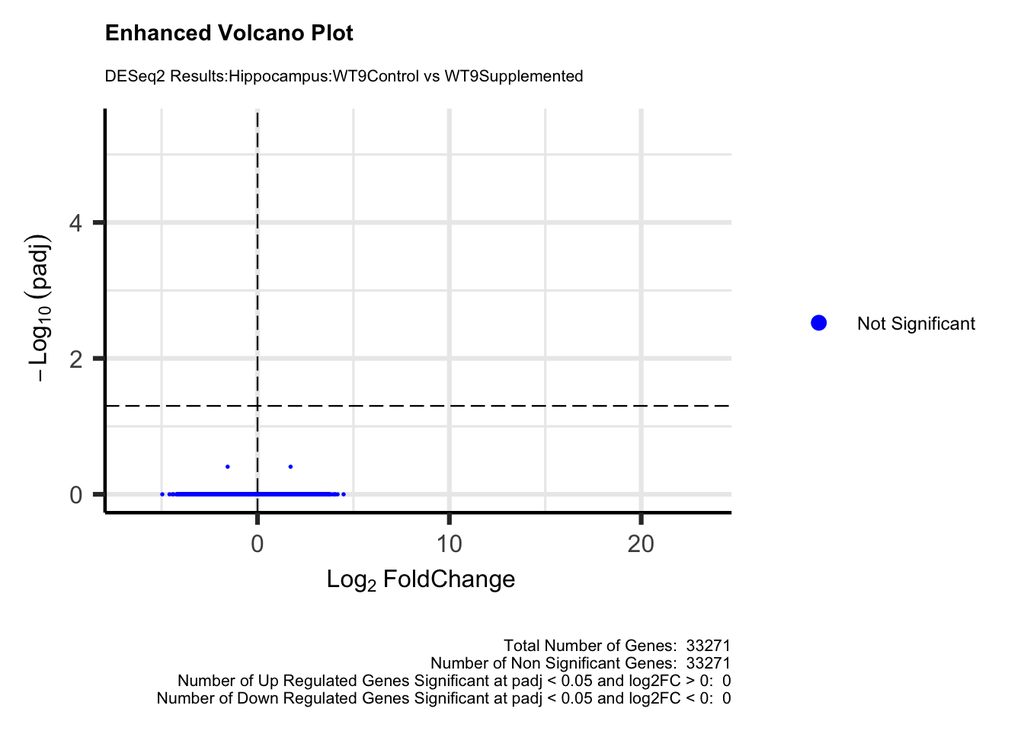

10. Hippocampus: Heatmap

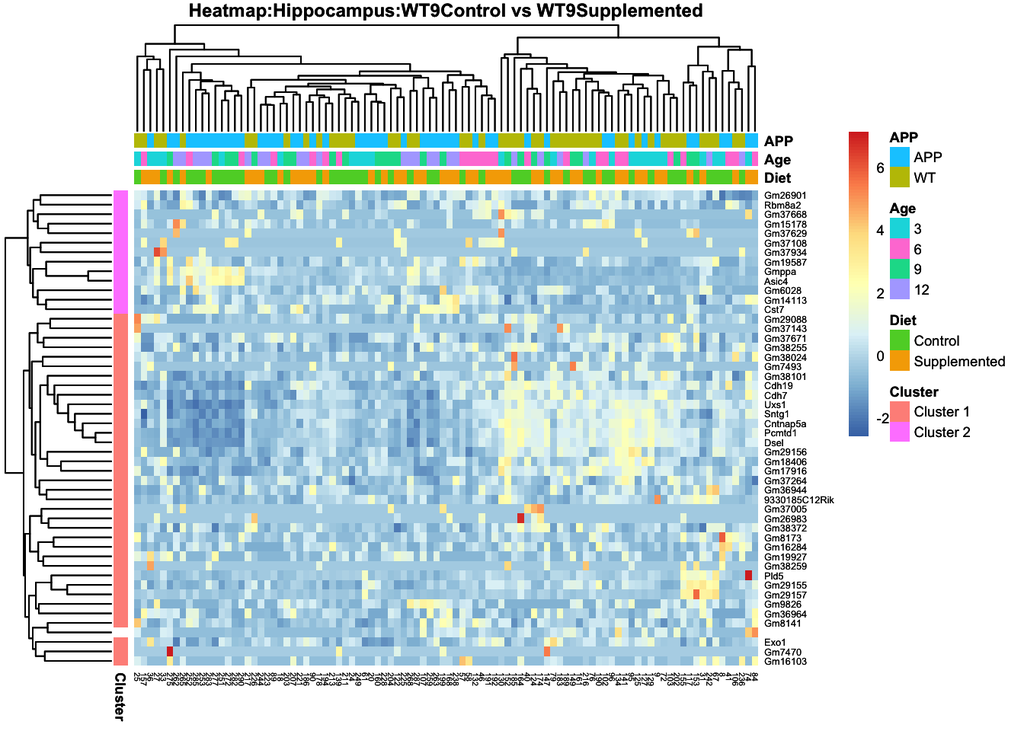

11. GSEA:Running fgsea

Perform a GSEA using a ranked list log2FoldChange values for all genes discovered in the DESeq2 results against the M2 Canonical Pathways gene set collection. Convert gene identifiers in the results to the appropriate matching format found in the M2 gene sets. fgsea expects a named vector of gene level statistics and the gene sets in the form of a named list.

Using “m2.cp.wikipathways.v0.3.symbols.gmt” which is the Canonical Pathways gene sets derived from the WikiPathways pathway database (WikiPathways subset of CP)

```
## # A tibble: 34,880 × 8
##    genes              volc_plot…¹ log2F…²     padj baseM…³ lfcSE   stat   pvalue
##    <chr>              <chr>         <dbl>    <dbl>   <dbl> <dbl>  <dbl>    <dbl>
##  1 ENSMUSG00000020872 DOWN        -18.2   5.39e-17    4.60 1.90  -9.53  1.55e-21
##  2 ENSMUSG00000084902 DOWN        -17.3   3.32e- 5    1.67 2.91  -5.94  2.86e- 9
##  3 ENSMUSG00000110266 UP           17.8   3.32e- 5    1.67 2.99   5.95  2.71e- 9
##  4 ENSMUSG00000050366 UP           16.7   3.86e- 4    1.42 3.05   5.47  4.44e- 8
##  5 ENSMUSG00000048620 NS          -17.4   6.01e- 2    2.42 3.91  -4.45  8.65e- 6
##  6 ENSMUSG00000057967 NS            0.802 7.97e- 1   76.2  0.210  3.81  1.37e- 4
##  7 ENSMUSG00000099974 NS           -3.09  8.41e- 1   13.5  0.829 -3.73  1.93e- 4
##  8 ENSMUSG00000064372 NS           -0.888 8.41e- 1  542.   0.238 -3.73  1.90e- 4
##  9 ENSMUSG00000111474 NS           -0.791 9.01e- 1   56.3  0.215 -3.68  2.33e- 4
## 10 ENSMUSG00000102628 NS           -0.249 1   e+ 0   17.9  0.469 -0.531 5.95e- 1
## # … with 34,870 more rows, and abbreviated variable names ¹volc_plot_status,
## #   ²log2FoldChange, ³baseMean
## # ℹ Use `print(n = ...)` to see more rows
```

```
## # A tibble: 190 × 8
##    pathway                       pval    padj log2err     ES   NES  size leadi…¹
##    <chr>                        <dbl>   <dbl>   <dbl>  <dbl> <dbl> <int> <list>
##  1 WP_NUCLEAR_RECEPTORS_IN_L… 2.28e-4 0.0144    0.519 -0.824 -1.95    29 <chr>
##  2 WP_OXIDATION_BY_CYTOCHROM… 6.92e-4 0.0263    0.477 -0.732 -1.82    39 <chr>
##  3 WP_TRYPTOPHAN_METABOLISM   4.86e-3 0.132     0.407 -0.704 -1.78    44 <chr>
##  4 WP_ESTROGEN_METABOLISM     1.01e-3 0.0319    0.455 -0.876 -1.69    12 <chr>
##  5 WP_AFLATOXIN_B1_METABOLISM 1.41e-5 0.00268   0.593 -0.992 -1.61     5 <chr>
##  6 WP_FATTY_ACID_OMEGAOXIDAT… 9.19e-3 0.195     0.381 -0.913 -1.54     6 <chr>
##  7 WP_FIBRIN_COMPLEMENT_RECE… 4.10e-2 0.648     0.322 -0.582 -1.46    43 <chr>
##  8 WP_METAPATHWAY_BIOTRANSFO… 1.48e-2 0.282     0.381 -0.489 -1.44   133 <chr>
##  9 WP_ELECTRON_TRANSPORT_CHA… 2.69e-2 0.464     0.352 -0.485 -1.38    97 <chr>
## 10 WP_OXIDATIVE_PHOSPHORYLAT… 5.90e-2 0.748     0.257 -0.515 -1.37    59 <chr>
## # … with 180 more rows, and abbreviated variable name ¹leadingEdge
## # ℹ Use `print(n = ...)` to see more rows
```

```
## Cortex NES ordered fgsea results saved in file: 'Cortex_NES_ordered_fgsea_results_Diet_WT_9_FC0.csv'
```

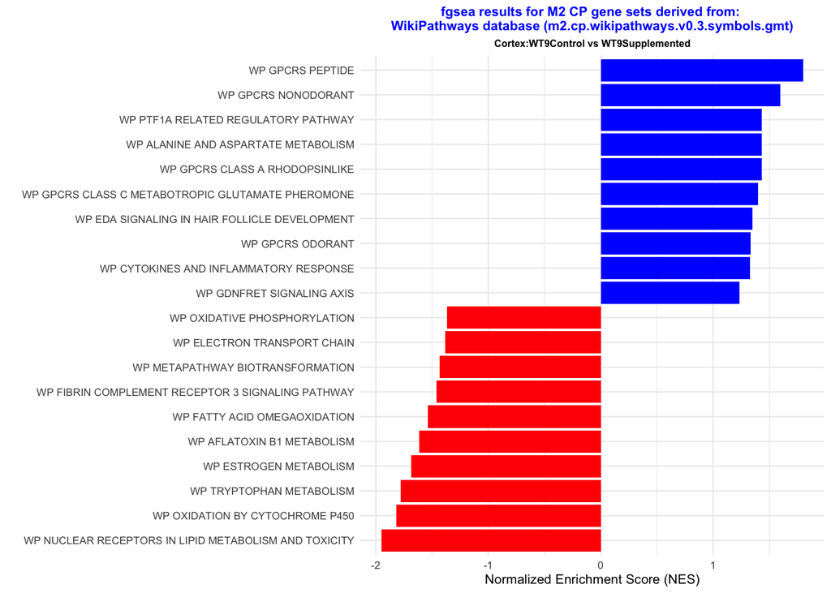

```
## # A tibble: 33,271 × 8
##    genes              volc_plot_st…¹ log2F…²  padj baseM…³ lfcSE    stat  pvalue
##    <chr>              <chr>            <dbl> <dbl>   <dbl> <dbl>   <dbl>   <dbl>
##  1 ENSMUSG00000084371 NS              1.72   0.393 1.24e+1 0.408  4.23   2.37e-5
##  2 ENSMUSG00000068129 NS             -1.56   0.393 9.33e+2 0.360 -4.33   1.52e-5
##  3 ENSMUSG00000102628 NS              0.500  1     4.93e+0 0.713  0.701  4.83e-1
##  4 ENSMUSG00000086053 NS              0.256  1     1.29e+0 1.57   0.163  8.70e-1
##  5 ENSMUSG00000102135 NS             -1.11   1     2.60e-1 4.99  -0.222  8.24e-1
##  6 ENSMUSG00000100764 NS             -0.585  1     7.79e+0 0.686 -0.853  3.93e-1
##  7 ENSMUSG00000100635 NS              1.49   1     1.06e+1 1.03   1.45   1.47e-1
##  8 ENSMUSG00000100480 NS             -0.183  1     4.09e+1 0.329 -0.558  5.77e-1
##  9 ENSMUSG00000100025 NS              0.0283 1     9.76e+0 0.522  0.0543 9.57e-1
## 10 ENSMUSG00000051285 NS             -0.0113 1     7.47e+3 0.225 -0.0503 9.60e-1
## # … with 33,261 more rows, and abbreviated variable names ¹volc_plot_status,
## #   ²log2FoldChange, ³baseMean
## # ℹ Use `print(n = ...)` to see more rows
```

```
## # A tibble: 190 × 8
##    pathway                         pval  padj log2err     ES   NES  size leadi…¹
##    <chr>                          <dbl> <dbl>   <dbl>  <dbl> <dbl> <int> <list>
##  1 WP_HYPOXIADEPENDENT_PROLIFER… 0.0664     1   0.238 -0.639 -1.39    19 <chr>
##  2 WP_HYPOXIADEPENDENT_SELFRENE… 0.0722     1   0.228 -0.674 -1.37    13 <chr>
##  3 WP_HYPOXIADEPENDENT_DIFFEREN… 0.167      1   0.146 -0.634 -1.28    13 <chr>
##  4 WP_FATTY_ACID_OMEGAOXIDATION  0.168      1   0.145 -0.759 -1.28     6 <chr>
##  5 WP_ESTROGEN_METABOLISM        0.214      1   0.126 -0.673 -1.24     9 <chr>
##  6 WP_FIBRIN_COMPLEMENT_RECEPTO… 0.141      1   0.154 -0.476 -1.24    42 <chr>
##  7 WP_OSTEOBLAST_SIGNALING       0.296      1   0.104 -0.631 -1.17     9 <chr>
##  8 WP_FACTORS_AND_PATHWAYS_AFFE… 0.249      1   0.115 -0.469 -1.15    31 <chr>
##  9 WP_MATRIX_METALLOPROTEINASES  0.262      1   0.113 -0.491 -1.14    24 <chr>
## 10 WP_BDNF_PATHWAY               0.316      1   0.100 -0.539 -1.13    15 <chr>
## # … with 180 more rows, and abbreviated variable name ¹leadingEdge
## # ℹ Use `print(n = ...)` to see more rows
```

```
## Hippocampus NES ordered fgsea results saved in file: 'Hippocampus_NES_ordered_fgsea_results_Diet_WT_9_FC0.csv'
```

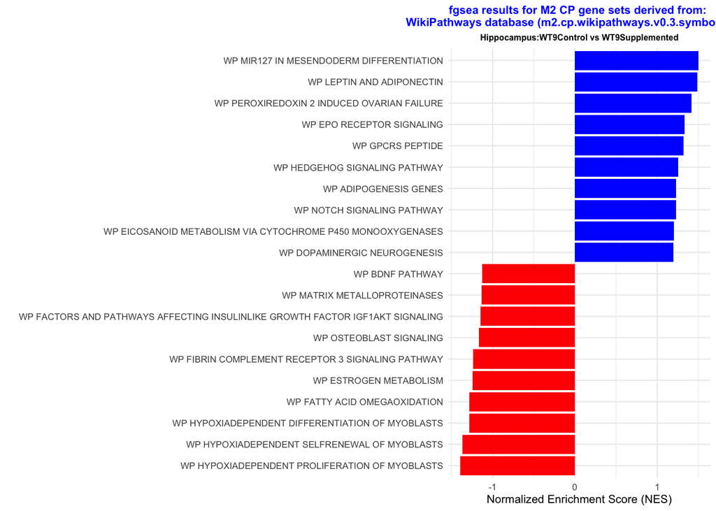